# Enfoque Electoral 2026

Análisis estructural del voto peruano y simulación de escenarios

Autor/a

Carlos Gino Garibotto Sandoval

Fecha de publicación

9 de marzo de 2026

## 1 Introducción

Este documento analiza el comportamiento estructural del electorado peruano usando datos de las elecciones presidenciales de 2021. El objetivo es identificar patrones territoriales del voto, cuantificar el electorado disponible, y simular escenarios para un candidato de centroizquierda moderada de cara a las elecciones de abril 2026.

El análisis parte de una pregunta ciudadana concreta: **¿por qué en Perú votamos y luego nos quejamos de que votamos mal?** La respuesta no es irracionalidad del votante, sino un sistema electoral que estructura mal las opciones disponibles. Con más de 18 candidatos en primera vuelta, el ganador puede llegar a segunda vuelta representando apenas al 15-19% del electorado. El 80% restante debe elegir entre dos opciones que no quería.

En ese contexto, un candidato de centroizquierda moderada con bajo antivoto y capacidad de consolidar el voto disperso tiene una ruta matemáticamente viable hacia la segunda vuelta. Este documento cuantifica esa ruta.

## 2 Datos y procesamiento

```
Distritos procesados: 1874
```

## 3 Cohesión del voto entre vueltas

```
FP 1ra ~ FP 2da: r = 0.802
PL 1ra ~ FP 2da: r = -0.842
```

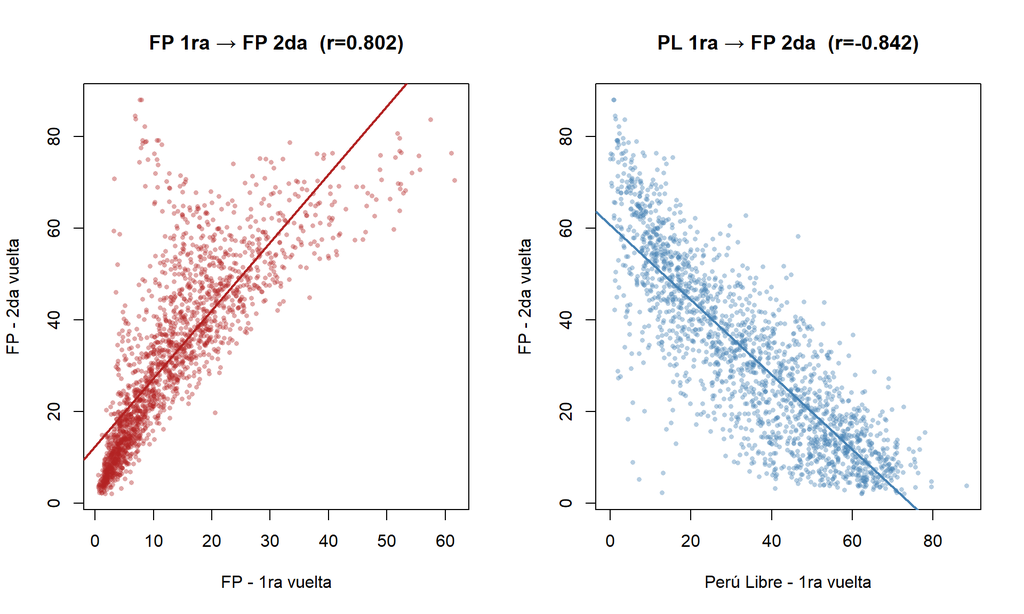

La correlación negativa entre el voto a Perú Libre en primera vuelta y el voto a Fuerza Popular en segunda vuelta (r=-0.842) es igualmente reveladora: los territorios donde Castillo fue más fuerte en primera vuelta fueron precisamente aquellos donde Fujimori fue más débil en segunda. Esta correlación no describe una transferencia de voto, sino la geografía de la polarización: el eje Fujimori-antifujimorismo estructura el territorio peruano de manera casi perfecta, convirtiendo la segunda vuelta en un referéndum binario con independencia de quiénes sean los candidatos.

Para un candidato de centroizquierda moderada en 2026, este patrón es simultáneamente una oportunidad y una trampa. La oportunidad está en que existe un vasto electorado que en primera vuelta vota por opciones fuera de ese eje, y que en segunda vuelta se ve obligado a elegir entre dos opciones que no quería. La trampa es que ese mismo electorado, en cuanto perciba que el candidato moderado no tiene opciones reales de llegar a segunda vuelta, activará el voto útil y migrará hacia el mal menor. El desafío estratégico central de 2026 no es ganar votos, sino convencer al electorado flotante de que votar por el candidato moderado no es tirar el voto.

## 4 Eje 1 — Territorios con voto disponible

Distribución de distritos y electores por tipo de territorio

| territorio_tipo | n_distritos | electores_total | pct_distritos | pct_electores |
| --- | --- | --- | --- | --- |
| Bastión FP | 139 | 1,023,628 | 7.4 | 4.2 |
| Bastión PL | 785 | 3,921,617 | 41.9 | 16.1 |
| Disputa moderada | 105 | 497,789 | 5.6 | 2.0 |
| Voto muy disperso | 845 | 18,847,887 | 45.1 | 77.6 |

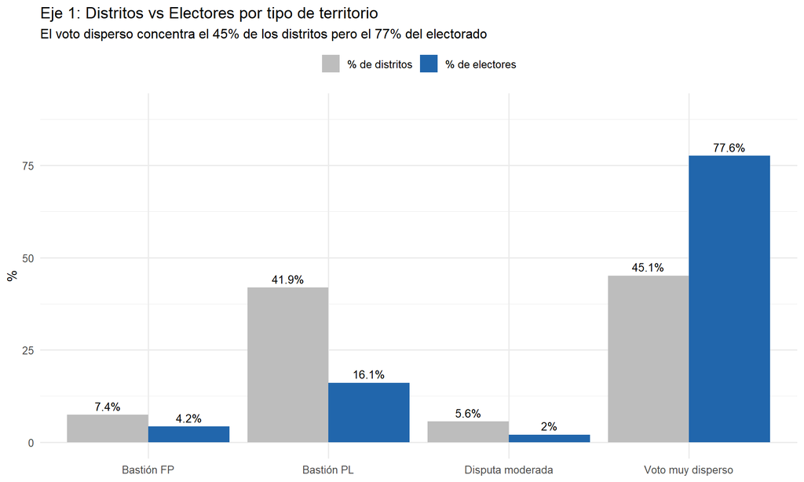

Que el 77% del electorado peruano habite en distritos donde ningún candidato dominó en primera vuelta es el dato estructural más importante del sistema electoral peruano contemporáneo. Este porcentaje no es una anomalía de 2021: es el resultado acumulado de dos décadas de fragmentación partidaria en las que ninguna fuerza política ha logrado construir una base territorial nacional consistente, con la excepción parcial del fujimorismo. En términos comparativos, Humala en 2011 logró consolidar ese voto disperso andino gracias a la narrativa de cambio; PPK en 2016 capturó el voto urbano de clase media mediante un perfil tecnocrático. Ambos llegaron a segunda vuelta con porcentajes de primera vuelta entre el 19% y el 26%, cifras que con el nivel de fragmentación proyectado para 2026 podrían estar al alcance de un candidato bien posicionado con entre 1.2 y 1.5 millones de votos.

La concentración del voto disperso en zonas urbanas y de mayor IDH no es casual. Responde a un patrón documentado en América Latina: el elector urbano con mayor nivel educativo y acceso a información es paradójicamente el más volátil, porque evalúa opciones con mayor autonomía y menor dependencia de redes partidarias. En el caso peruano, este elector ha experimentado la decepción sucesiva de Toledo, García, Humala, Kuczynski y Sagasti, lo que ha producido un escepticismo estructural hacia cualquier candidato establecido. Este escepticismo es el recurso político más valioso para un candidato nuevo con credenciales técnicas y bajo antivoto.

## 5 Eje 2 — Perfil del votante flotante

Perfil del votante flotante por cuartil IDH

| cuartil_idh | idh_media | otros_1ra_media | nulos_media | participacion | n |
| --- | --- | --- | --- | --- | --- |
| Q1 - IDH bajo | 0.247 | 44.8 | 6.1 | 65.4 | 469 |
| Q2 | 0.345 | 48.7 | 5.7 | 66.9 | 469 |
| Q3 | 0.442 | 51.7 | 5.6 | 70.6 | 468 |
| Q4 - IDH alto | 0.604 | 62.0 | 5.8 | 76.2 | 468 |

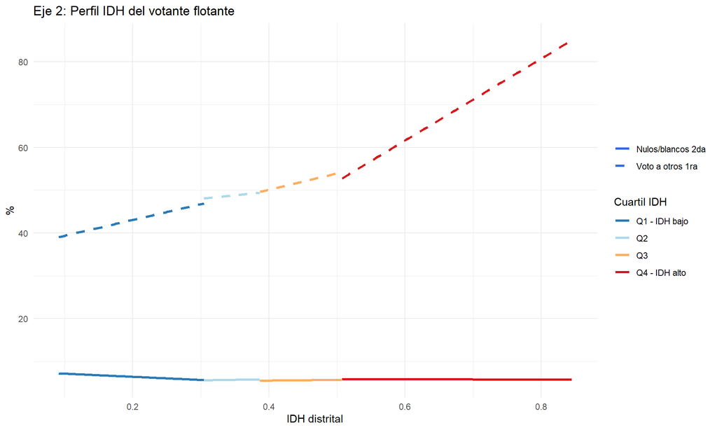

La diferencia en el perfil del votante flotante según nivel de IDH revela dos mercados electorales distintos que un candidato de centroizquierda moderada debe gestionar simultáneamente con mensajes diferenciados. En los distritos de IDH bajo, el voto a candidatos menores en primera vuelta es más reducido porque la oferta política está más segmentada entre los bastiones de FP y PL; el elector de bajos ingresos responde a incentivos más concretos: propuestas de empleo, infraestructura y servicios, no narrativas abstractas de reforma institucional. El votante flotante de estos territorios existe pero es menos numeroso y más difícil de movilizar sin presencia territorial directa.

En los distritos de IDH alto, el voto disperso es estructuralmente mayor porque el elector urbano con mayor nivel educativo rechaza con más frecuencia las opciones dominantes del eje polarizado. Este segmento es el más accesible para un candidato de centroizquierda moderada con credenciales técnicas, pero también el más exigente: responde a propuestas concretas de política pública, no a populismo, y castiga duramente la incoherencia programática o los escándalos de corrupción. Es un electorado que puede ser ganado pero no dado por descontado.

El principal riesgo de pérdida en ambos segmentos es la irrupción de un outsider con alta visibilidad mediática. El patrón peruano desde 2001 muestra que el elector flotante tiene baja fidelidad y alta sensibilidad al momentum de campaña: si en los últimos tres meses antes de la elección emerge un candidato percibido como más viable o más rupturista, el flotante migra con rapidez. La estrategia defensiva no es competir en el terreno del outsider, sino anclar la candidatura en una propuesta técnica sólida que genere confianza diferenciada y sea difícil de replicar por un improvisado.

## 6 Eje 3 — Kingmaker: poder del 3er candidato

```
Distritos que cambiarían: 273 de 1874 (14.6%)
```

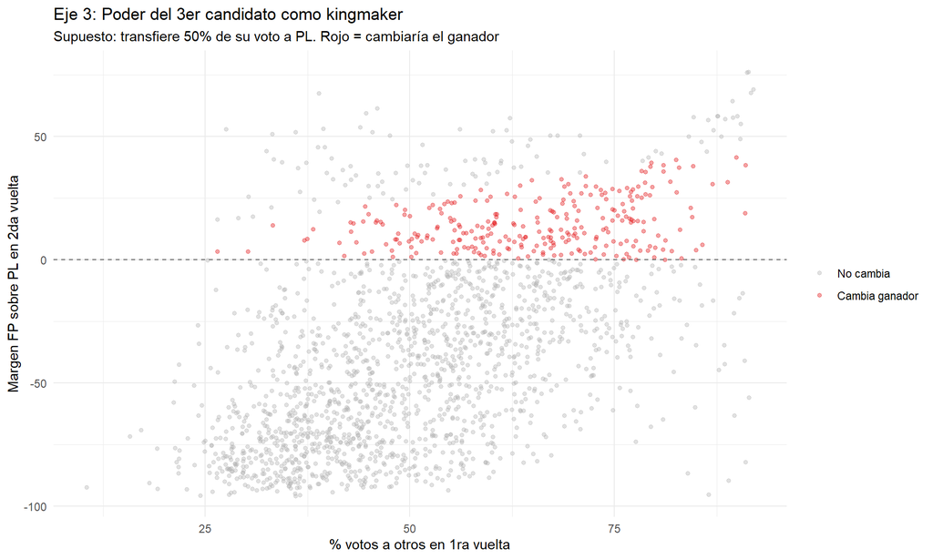

Que el 14.6% de los distritos peruanos habría cambiado de ganador en 2021 si un tercer candidato hubiera transferido la mitad de su voto a Perú Libre ilustra con precisión matemática el poder estructural de la tercera posición en el sistema electoral peruano. Con un margen nacional de apenas 44,000 votos entre Castillo y Fujimori, la capacidad de transferencia de un candidato con 800,000 o más votos en primera vuelta no es marginal: es determinante. Este poder de negociación es real, pero su ejercicio en el contexto político peruano ha sido históricamente mal gestionado por los actores que lo han detentado.

La historia del voto útil en Perú ofrece tres lecciones distintas. En 2011, Humala construyó una coalición amplia de segunda vuelta apelando al antifujimorismo; la transferencia fue orgánica porque su posicionamiento de izquierda moderada generó afinidad natural con los candidatos eliminados. En 2016, PPK se benefició del voto útil anti-Keiko de sectores liberales urbanos sin necesitar un acuerdo formal; la transferencia fue ideológicamente coherente aunque programáticamente vacía. En 2021, Castillo recibió transferencia del voto disperso anti-Fujimori por default, no por convicción programática, lo que explica en parte la volatilidad de su gobierno posterior. El patrón común es que el voto útil funciona cuando hay un eje claro de rechazo al adversario, no cuando hay una propuesta atractiva del beneficiario.

Para un candidato de centroizquierda moderada en 2026, la disyuntiva entre ser kingmaker o competir por segunda vuelta no es una decisión estratégica libre sino una función del contexto electoral que se irá definiendo entre seis y tres meses antes de la elección. Si las encuestas muestran viabilidad real de llegar a segunda vuelta, la estrategia debe ser competir directamente y evitar compromisos de transferencia que limiten la libertad programática posterior. Si en los últimos meses el escenario muestra que la segunda vuelta entre FP y una alternativa radical es probable, el poder de negociación del candidato moderado como árbitro es su activo más valioso y debe ser administrado con precisión.

## 7 Mapa georreferenciado

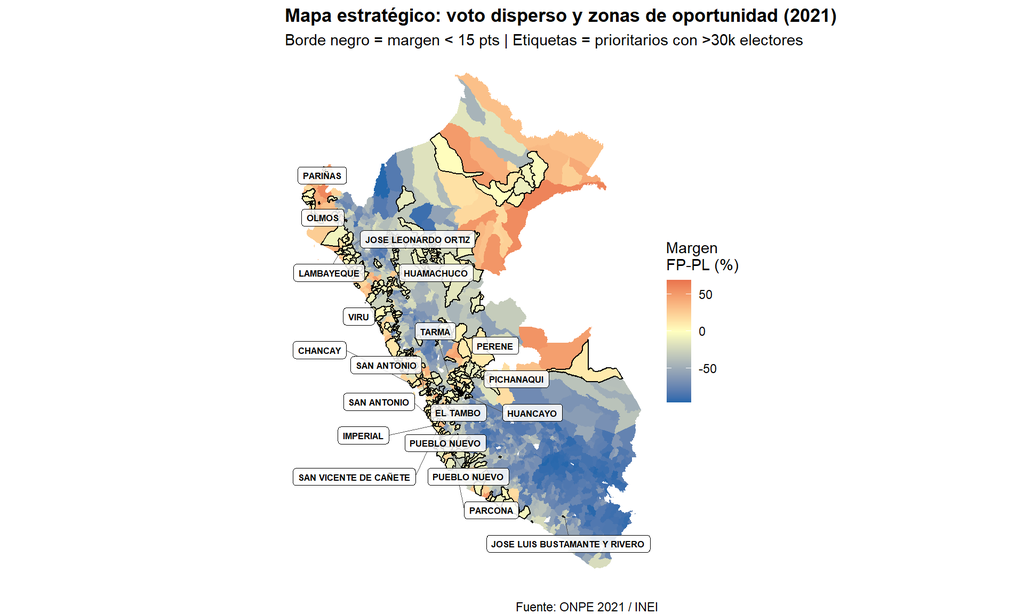

El mapa de competitividad electoral del Perú 2021 revela una geografía de oportunidad que no coincide con los imaginarios políticos dominantes. Los distritos competitivos, aquellos donde el margen entre FP y PL fue menor a 15 puntos porcentuales, se concentran en la franja costera norte y centro, los valles interandinos de mediana altitud y los conos urbanos de Lima y Callao. Esta distribución no es aleatoria: coincide con los territorios de IDH medio-alto, economías diversificadas y electorados con mayor nivel educativo, es decir, exactamente los territorios donde el voto disperso es más alto y donde el elector evalúa opciones con mayor autonomía respecto a las redes partidarias tradicionales.

Los cuatro territorios más estratégicos para un candidato de centroizquierda moderada son, por razones distintas, los siguientes. Lima Metropolitana y Callao son ineludibles por volumen: concentran cerca del 35% del electorado nacional y tienen la mayor proporción de voto disperso urbano, pero requieren una estrategia de alta exposición mediática y propuesta de política urbana concreta. La Libertad y Lambayeque forman un corredor costero norte con fuerte identidad regional y economías agroindustriales; este territorio fue clave para Kuczynski en 2016 y es recuperable para un perfil similar pero con mayor contenido social. Arequipa es el termómetro político del Perú: su electorado sofisticado y regionalista ha apoyado consistentemente a terceras opciones cuando percibe que ninguno de los candidatos dominantes los representa, y su respaldo opera como señal de credibilidad para el resto del país. Junín y el corredor central son el territorio de mayor riesgo y mayor potencial: alta movilidad electoral, economías mineras y agrícolas en tensión, y un electorado que en 2021 dividió su voto entre PL en bastiones rurales y dispersión en zonas urbanas.

La concentración del potencial electoral en Lima tiene implicancias directas para la asignación de recursos de campaña. Un candidato que destine más del 50% de su presupuesto de comunicación a Lima no está sobreinvirtiendo en la capital: está siendo eficiente, porque Lima no solo concentra votos sino que genera el efecto de credibilidad nacional que determina si el candidato es percibido como viable o marginal en el resto del país.

## 8 Índice de afinidad y simulación — López Chau

Simulación de votos — López Chau 2026

| Escenario | Votos | % del total 2021 | ¿Pasa a 2da vuelta? |
| --- | --- | --- | --- |
| Pesimista (8%) | 895,928 | 5.1 | No |
| Moderado (15%) | 1,679,876 | 9.6 | En el límite |
| Optimista (22%) | 2,463,831 | 14.1 | Sí |

Simulación de votos por departamento en tres escenarios

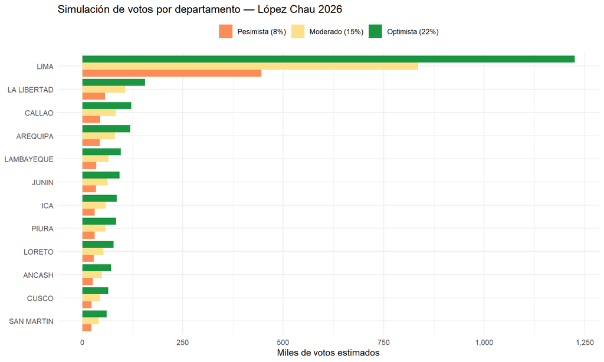

Simulación de votos por departamento en tres escenarios

La simulación para un candidato de centroizquierda moderada en 2026 arroja un rango de entre 895,928 y 2,463,831 votos dependiendo de la tasa de captura del voto disperso, con el escenario moderado de 1,679,876 votos situándose por encima del umbral histórico de 1.2-1.5 millones necesario para competir por segunda vuelta en un contexto de alta fragmentación. La comparación histórica más pertinente es con Alejandro Toledo en 2001, que llegó a segunda vuelta con 1.9 millones de votos en primera vuelta, y con PPK en 2016, que pasó con 3.2 millones en un contexto de menor fragmentación. El escenario moderado es matemáticamente viable, pero su traducción en votos reales requiere condiciones de campaña que no están garantizadas.

Las condiciones que convertirían el escenario moderado en optimista son, en orden de importancia: primero, que el candidato logre consolidar en los primeros seis meses una imagen de competencia técnica y probidad que lo diferencie nítidamente de los candidatos del eje polarizado; segundo, que la fragmentación de la oferta política de centroizquierda moderada no se disperse entre tres o cuatro candidatos similares, lo que requiere ya sea una coalición temprana o una diferenciación muy marcada de propuesta; tercero, que Lima valide la candidatura con encuestas de dos dígitos antes de octubre de 2025, activando el efecto de viabilidad que determina el comportamiento del elector estratégico. Sin estas tres condiciones simultáneas, el escenario moderado es el techo, no el piso.

Los tres principales riesgos de caída por debajo del escenario pesimista son los siguientes. El primero es la irrupción de un outsider mediático con alta visibilidad en los últimos cuatro meses de campaña, que puede absorber hasta el 40% del voto flotante identificado antes de que el candidato moderado pueda consolidarlo. El segundo es un escándalo de corrupción o inconsistencia programática que active el rechazo del elector urbano de IDH alto, que es el segmento más sensible a la credibilidad y el más rápido en migrar. El tercero es la activación del voto útil anti-FP o anti-PL en segunda vuelta antes de que el candidato llegue a ella, lo que comprime el espacio de la tercera opción en las semanas finales de la primera vuelta.

La recomendación territorial para los primeros seis meses de campaña tiene una lógica secuencial clara. El candidato debe iniciar con presencia intensiva en Lima, no para ganar Lima sino para construir la percepción nacional de viabilidad que es condición de todo lo demás. Simultáneamente debe anclar territorialmente en Arequipa, donde el respaldo regional opera como validación de credibilidad ante el electorado nacional. En el tercer mes debe abrir frente en La Libertad y Lambayeque con propuesta específica de desarrollo agroindustrial y empleo costero. Recién en el cuarto mes, con base territorial consolidada en estos tres ejes, tiene sentido invertir recursos en Junín y el corredor central, donde el costo de campaña es alto y el resultado incierto sin una base de credibilidad previa.

## 9 Conclusiones

1. **El voto peruano es estructuralmente cohesionado** (r > 0.80) pero la fragmentación en primera vuelta lo diluye.
2. **El 77% del electorado vive en distritos de voto disperso** — no votan mal, el sistema los obliga a elegir entre opciones que no querían.
3. **López Chau tiene un territorio real de oportunidad**: Lima (50% de sus votos potenciales), La Libertad, Callao, Arequipa y Lambayeque explican el 70% de su resultado posible.
4. **El umbral para segunda vuelta** con 20+ candidatos es ~1.2–1.5 millones de votos. El escenario moderado lo sitúa en 1.68M.
5. **El principal riesgo es el outsider impredecible**: el 38% del electorado prefiere a alguien que no figura en las encuestas.

*Datos: ONPE 2021 / INEI. Los escenarios son ejercicios de análisis político, no pronósticos electorales.*

*Los análisis interpretativos fueron generados con asistencia de Claude (Anthropic) como agente de análisis político, con supervisión y validación del autor.*